# Sand Production problems

Sand production occurs when the stress on the formation exceeds the formation strength and result in rock failure. Rock failure happens due to tectonic activities, overburden pressure, pore pressure, stress induced during drilling and also producing fluid drag force

firstly , import the data

```python
#data loading and descriptive statistics
import pandas as pd
data=pd.read_csv('D:/python/my work/hoss/Chapter-7/Chapter 7/Chapter7_Sand Production.CSV')
data
```

|  | No | TVD | TT | COH | Qg | Qw | BHFP | DD | EOVS | SPF | Hperf | Sand Production Observed |
| --- | --- | --- | --- | --- | --- | --- | --- | --- | --- | --- | --- | --- |
| 0 | 1 | 319 | 105 | 22.0 | 42.3 | 5672.000 | 133.2 | 27.8 | 651 | 4.0 | 14.0 | 1 |
| 1 | 2 | 3182 | 105 | 21.9 | 51.2 | 68.000 | 140.4 | 16.6 | 642 | 4.0 | 16.0 | 1 |
| 2 | 3 | 3366 | 100 | 24.7 | 66.9 | 157.000 | 156.2 | 18.9 | 601 | 4.0 | 6.0 | 1 |
| 3 | 4 | 3647 | 100 | 29.6 | 80.6 | 85.000 | 153.8 | 57.8 | 670 | 8.0 | 20.0 | 1 |
| 4 | 5 | 4548 | 85 | 53.2 | 48.0 | 886.000 | 209.1 | 58.9 | 823 | 4.0 | 18.0 | 1 |
| 5 | 6 | 4088 | 85 | 39.5 | 72.7 | 116.000 | 147.0 | 44.0 | 781 | 2.0 | 17.0 | 1 |
| 6 | 7 | 2100 | 115 | 10.8 | 28.5 | 724.000 | 160.1 | 8.9 | 300 | 4.0 | 15.5 | 1 |
| 7 | 8 | 1930 | 132 | 9.7 | 27.5 | 695.000 | 175.5 | 11.2 | 245 | 4.0 | 11.5 | 1 |
| 8 | 9 | 2139 | 112 | 11.1 | 36.8 | 280.000 | 185.5 | 6.1 | 283 | 4.0 | 10.5 | 1 |
| 9 | 10 | 2380 | 110 | 13.0 | 23.0 | 42.000 | 113.0 | 47.4 | 413 | 6.0 | 11.0 | 1 |
| 10 | 11 | 1122 | 150 | 5.7 | 108.0 | 0.000 | 107.0 | 8.0 | 115 | 12.0 | 10.5 | 1 |
| 11 | 12 | 1340 | 130 | 6.6 | 51.0 | 52.000 | 126.6 | 14.4 | 140 | 12.0 | 6.5 | 1 |
| 12 | 13 | 1070 | 170 | 5.5 | 82.0 | 70.000 | 103.8 | 0.7 | 111 | 4.0 | 9.0 | 1 |
| 13 | 14 | 1920 | 130 | 9.6 | 111.0 | 0.000 | 248.0 | 82.0 | 153 | 4.0 | 9.0 | 1 |
| 14 | 15 | 2530 | 100 | 14.3 | 58.0 | 68.000 | 302.2 | 97.8 | 242 | 4.0 | 4.5 | 1 |
| 15 | 16 | 1640 | 145 | 8.0 | 94.0 | 1260.000 | 189.0 | 46.8 | 150 | 12.0 | 10.0 | 1 |
| 16 | 17 | 2130 | 120 | 11.0 | 86.0 | 112.000 | 268.3 | 31.7 | 179 | 4.0 | 3.5 | 1 |
| 17 | 18 | 3655 | 100 | 19.8 | 69.8 | 1780.000 | 287.6 | 9.1 | 553 | 4.0 | 21.0 | 1 |
| 18 | 19 | 3668 | 100 | 30.0 | 75.8 | 150.000 | 272.3 | 9.2 | 571 | 4.0 | 21.0 | 1 |
| 19 | 20 | 1503 | 125 | 7.3 | 139.5 | 35.000 | 152.3 | 2.2 | 177 | 4.0 | 11.5 | 1 |
| 20 | 21 | 3170 | 100 | 21.7 | 48.0 | 2823.000 | 222.1 | 6.4 | 485 | 4.0 | 16.0 | 1 |
| 21 | 22 | 3197 | 95 | 22.1 | 73.0 | 273.000 | 184.6 | 48.6 | 535 | 2.0 | 12.0 | 0 |
| 22 | 23 | 3230 | 105 | 22.6 | 117.0 | 68.000 | 210.0 | 10.0 | 517 | 27.0 | 4.0 | 0 |
| 23 | 24 | 3684 | 95 | 30.3 | 108.7 | 36.000 | 266.6 | 59.7 | 581 | 1.0 | 12.0 | 0 |
| 24 | 25 | 3005 | 93 | 19.5 | 55.0 | 91.000 | 67.0 | 1.0 | 615 | 33.0 | 4.0 | 0 |
| 25 | 26 | 3790 | 85 | 32.5 | 93.4 | 77.000 | 217.2 | 124.4 | 654 | 8.5 | 12.0 | 0 |
| 26 | 27 | 2750 | 98 | 16.5 | 125.8 | 75.000 | 251.8 | 3.0 | 372 | 8.5 | 4.0 | 0 |
| 27 | 28 | 2983 | 98 | 19.2 | 48.0 | 28.000 | 102.0 | 6.1 | 581 | 12.0 | 4.0 | 0 |
| 28 | 29 | 3175 | 100 | 21.8 | 30.3 | 1.698 | 216.1 | 17.1 | 492 | 20.0 | 4.0 | 0 |

```python
data.columns
```

```
Index(['No', 'TVD', 'TT', 'COH', 'Qg', 'Qw', 'BHFP', 'DD', 'EOVS', 'SPF',
       'Hperf', 'Sand Production Observed'],
      dtype='object')
```

```python
data.rename(columns={'TVD':'True Vertical Depth',"TT":"Transit Time","DD":"Drawdown pressure","COH":"Cohesive strength of formation","EOVS":"Effective overburden stress","SPF":"Shots per foot","Hperf":"Perforation interval",}, inplace=True)
df=data.drop(columns="No",axis=1)
df
```

|  | True Vertical Depth | Transit Time | Cohesive strength of formation | Qg | Qw | BHFP | Drawdown pressure | Effective overburden stress | Shots per foot | Perforation interval | Sand Production Observed |
| --- | --- | --- | --- | --- | --- | --- | --- | --- | --- | --- | --- |
| 0 | 319 | 105 | 22.0 | 42.3 | 5672.000 | 133.2 | 27.8 | 651 | 4.0 | 14.0 | 1 |
| 1 | 3182 | 105 | 21.9 | 51.2 | 68.000 | 140.4 | 16.6 | 642 | 4.0 | 16.0 | 1 |
| 2 | 3366 | 100 | 24.7 | 66.9 | 157.000 | 156.2 | 18.9 | 601 | 4.0 | 6.0 | 1 |
| 3 | 3647 | 100 | 29.6 | 80.6 | 85.000 | 153.8 | 57.8 | 670 | 8.0 | 20.0 | 1 |
| 4 | 4548 | 85 | 53.2 | 48.0 | 886.000 | 209.1 | 58.9 | 823 | 4.0 | 18.0 | 1 |
| 5 | 4088 | 85 | 39.5 | 72.7 | 116.000 | 147.0 | 44.0 | 781 | 2.0 | 17.0 | 1 |
| 6 | 2100 | 115 | 10.8 | 28.5 | 724.000 | 160.1 | 8.9 | 300 | 4.0 | 15.5 | 1 |
| 7 | 1930 | 132 | 9.7 | 27.5 | 695.000 | 175.5 | 11.2 | 245 | 4.0 | 11.5 | 1 |
| 8 | 2139 | 112 | 11.1 | 36.8 | 280.000 | 185.5 | 6.1 | 283 | 4.0 | 10.5 | 1 |
| 9 | 2380 | 110 | 13.0 | 23.0 | 42.000 | 113.0 | 47.4 | 413 | 6.0 | 11.0 | 1 |
| 10 | 1122 | 150 | 5.7 | 108.0 | 0.000 | 107.0 | 8.0 | 115 | 12.0 | 10.5 | 1 |
| 11 | 1340 | 130 | 6.6 | 51.0 | 52.000 | 126.6 | 14.4 | 140 | 12.0 | 6.5 | 1 |
| 12 | 1070 | 170 | 5.5 | 82.0 | 70.000 | 103.8 | 0.7 | 111 | 4.0 | 9.0 | 1 |
| 13 | 1920 | 130 | 9.6 | 111.0 | 0.000 | 248.0 | 82.0 | 153 | 4.0 | 9.0 | 1 |
| 14 | 2530 | 100 | 14.3 | 58.0 | 68.000 | 302.2 | 97.8 | 242 | 4.0 | 4.5 | 1 |
| 15 | 1640 | 145 | 8.0 | 94.0 | 1260.000 | 189.0 | 46.8 | 150 | 12.0 | 10.0 | 1 |
| 16 | 2130 | 120 | 11.0 | 86.0 | 112.000 | 268.3 | 31.7 | 179 | 4.0 | 3.5 | 1 |
| 17 | 3655 | 100 | 19.8 | 69.8 | 1780.000 | 287.6 | 9.1 | 553 | 4.0 | 21.0 | 1 |
| 18 | 3668 | 100 | 30.0 | 75.8 | 150.000 | 272.3 | 9.2 | 571 | 4.0 | 21.0 | 1 |
| 19 | 1503 | 125 | 7.3 | 139.5 | 35.000 | 152.3 | 2.2 | 177 | 4.0 | 11.5 | 1 |
| 20 | 3170 | 100 | 21.7 | 48.0 | 2823.000 | 222.1 | 6.4 | 485 | 4.0 | 16.0 | 1 |
| 21 | 3197 | 95 | 22.1 | 73.0 | 273.000 | 184.6 | 48.6 | 535 | 2.0 | 12.0 | 0 |
| 22 | 3230 | 105 | 22.6 | 117.0 | 68.000 | 210.0 | 10.0 | 517 | 27.0 | 4.0 | 0 |
| 23 | 3684 | 95 | 30.3 | 108.7 | 36.000 | 266.6 | 59.7 | 581 | 1.0 | 12.0 | 0 |
| 24 | 3005 | 93 | 19.5 | 55.0 | 91.000 | 67.0 | 1.0 | 615 | 33.0 | 4.0 | 0 |
| 25 | 3790 | 85 | 32.5 | 93.4 | 77.000 | 217.2 | 124.4 | 654 | 8.5 | 12.0 | 0 |
| 26 | 2750 | 98 | 16.5 | 125.8 | 75.000 | 251.8 | 3.0 | 372 | 8.5 | 4.0 | 0 |
| 27 | 2983 | 98 | 19.2 | 48.0 | 28.000 | 102.0 | 6.1 | 581 | 12.0 | 4.0 | 0 |
| 28 | 3175 | 100 | 21.8 | 30.3 | 1.698 | 216.1 | 17.1 | 492 | 20.0 | 4.0 | 0 |

```python
# Import Libraries
from sklearn.preprocessing import StandardScaler
from sklearn.impute import SimpleImputer
import numpy as np
from sklearn.feature_selection import SelectKBest
from sklearn.feature_selection import chi2 , f_classif
from sklearn.ensemble import RandomForestClassifier
from sklearn.ensemble import GradientBoostingClassifier
from sklearn.naive_bayes import GaussianNB
from sklearn.linear_model import LogisticRegression
from sklearn.discriminant_analysis import LinearDiscriminantAnalysis
from sklearn.svm import SVC
from sklearn.tree import DecisionTreeClassifier
from sklearn.neighbors import KNeighborsClassifier
from sklearn.neural_network import MLPClassifier
from sklearn.metrics import confusion_matrix
import seaborn as sns
import matplotlib.pyplot as plt
from sklearn.metrics import accuracy_score
from sklearn.metrics import f1_score
from sklearn.metrics import classification_report
import seaborn as sns
import pandas as pd
import matplotlib.pyplot as plt
from sklearn.model_selection import train_test_split
```

```python
df.describe().transpose()
```

|  | count | mean | std | min | 25% | 50% | 75% | max |
| --- | --- | --- | --- | --- | --- | --- | --- | --- |
| True Vertical Depth | 29.0 | 2664.172414 | 1027.947680 | 319.0 | 1930.0 | 2983.0 | 3366.0 | 4548.0 |
| Transit Time | 29.0 | 109.931034 | 20.476347 | 85.0 | 98.0 | 100.0 | 120.0 | 170.0 |
| Cohesive strength of formation | 29.0 | 19.293103 | 11.056444 | 5.5 | 10.8 | 19.5 | 22.6 | 53.2 |
| Qg | 29.0 | 70.751724 | 31.720460 | 23.0 | 48.0 | 69.8 | 93.4 | 139.5 |
| Qw | 29.0 | 542.230966 | 1171.726103 | 0.0 | 52.0 | 85.0 | 280.0 | 5672.0 |
| BHFP | 29.0 | 185.113793 | 62.763364 | 67.0 | 140.4 | 184.6 | 222.1 | 302.2 |
| Drawdown pressure | 29.0 | 30.200000 | 31.623466 | 0.7 | 8.0 | 16.6 | 47.4 | 124.4 |
| Effective overburden stress | 29.0 | 435.586207 | 217.682849 | 111.0 | 242.0 | 492.0 | 601.0 | 823.0 |
| Shots per foot | 29.0 | 7.724138 | 7.457722 | 1.0 | 4.0 | 4.0 | 8.5 | 33.0 |
| Perforation interval | 29.0 | 10.965517 | 5.499888 | 3.5 | 6.0 | 11.0 | 15.5 | 21.0 |
| Sand Production Observed | 29.0 | 0.724138 | 0.454859 | 0.0 | 0.0 | 1.0 | 1.0 | 1.0 |

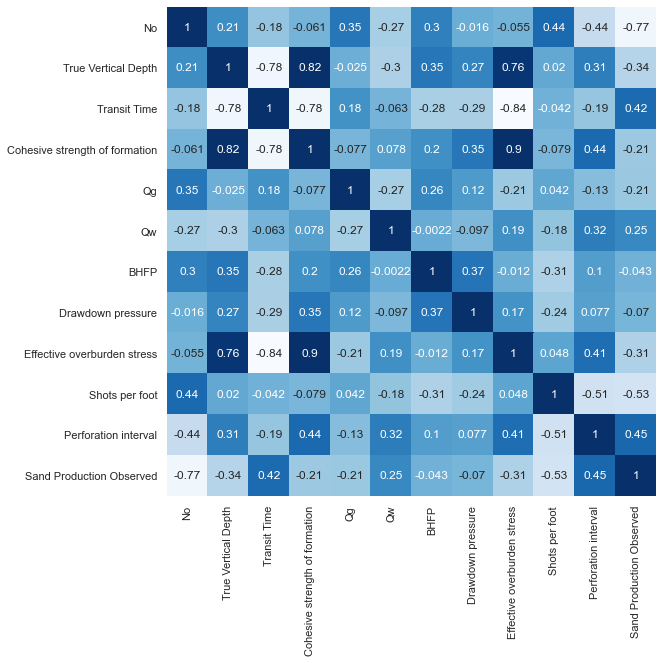

```python
import seaborn as sns

#correlation matrix
corrmat = data.corr()
f, ax = plt.subplots(figsize=(12, 9))
sns.heatmap(corrmat, vmax=.8, square=True,cmap="Blues",annot=True,cbar=False)
```

```
D:\python\New folder\lib\site-packages\seaborn\axisgrid.py:1912: UserWarning: The `size` parameter has been renamed to `height`; please update your code.
  warnings.warn(msg, UserWarning)
```

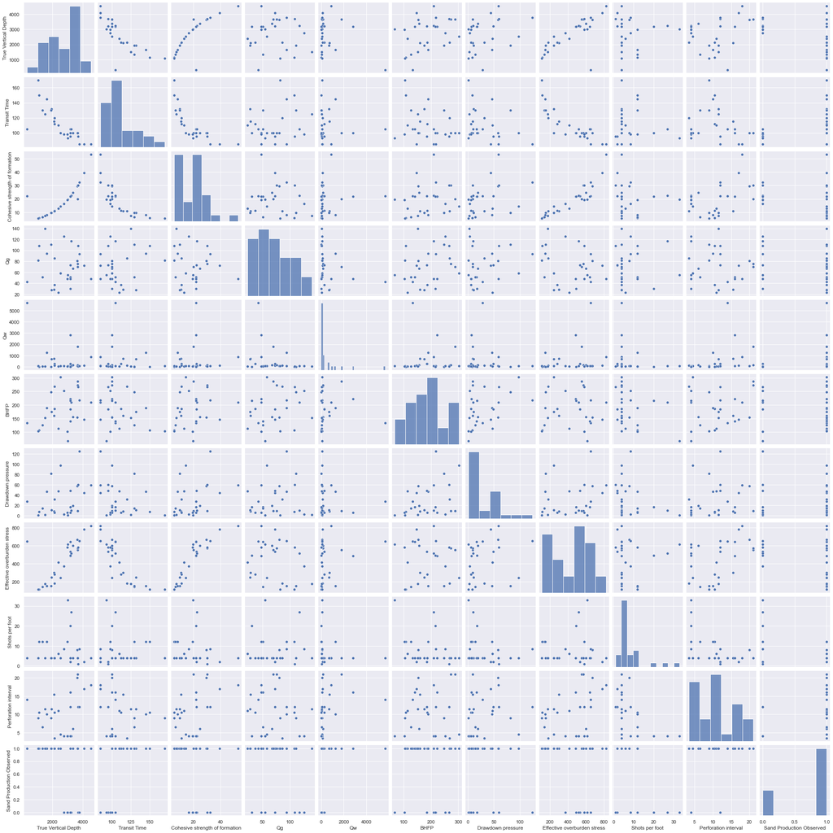

```python
sns.set()
sns.pairplot(df, size = 2.5)
plt.show()
```

```python
df.columns
```

```
Index(['True Vertical Depth', 'Transit Time', 'Cohesive strength of formation',
       'Qg', 'Qw', 'BHFP', 'Drawdown pressure', 'Effective overburden stress',
       'Shots per foot', 'Perforation interval', 'Sand Production Observed'],
      dtype='object')
```

[output not shown]

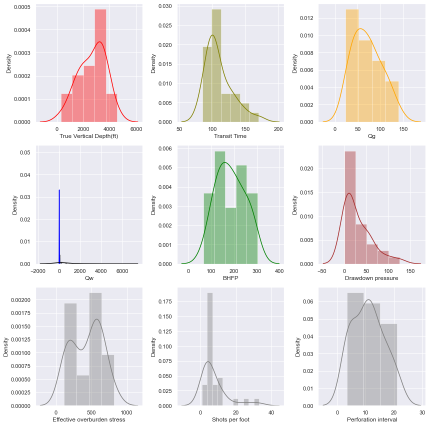

```python
f, axes =plt.subplots(3, 3, figsize=(12, 12))
sns.distplot(df['True Vertical Depth'], color="red", ax=axes[0, 0],
axlabel='True Vertical Depth(ft)')

sns.distplot(df['Transit Time'], color="olive", ax=axes[0, 1],
axlabel='Transit Time')

sns.distplot(df['Cohesive strength of formation'],color="blue",ax=axes[1,0],axlabel='Cohesive strength of formation')

#sns.distplot(df['Rate Of Penetration'], color="blue", ax=axes
#[1, 0],axlabel='Rate of Penetration (ft/hr)')

sns.distplot(df['Qg'], color="orange", ax=axes[0,2],
axlabel='Qg')

sns.distplot(df['Qw'], color="black",
ax=axes[1, 0],axlabel='Qw')

sns.distplot(df['BHFP'], color="green",
ax=axes[1, 1],axlabel='BHFP')

sns.distplot(df['Drawdown pressure'], color="brown",
ax=axes[1, 2],axlabel='Drawdown pressure')

sns.distplot(df['Effective overburden stress'], color="gray", ax=axes[2, 0],
axlabel='Effective overburden stress')


sns.distplot(df['Shots per foot'], color="gray", ax=axes[2, 1],
axlabel='Shots per foot')

sns.distplot(df['Perforation interval'], color="gray", ax=axes[2, 2],
axlabel='Perforation interval')


#sns.distplot(df["Rate Of Penetration"],color="red",ax=axes[3,1],
#axlabel="Rate of pentration")
plt.tight_layout()
plt.show()
```

[output not shown]

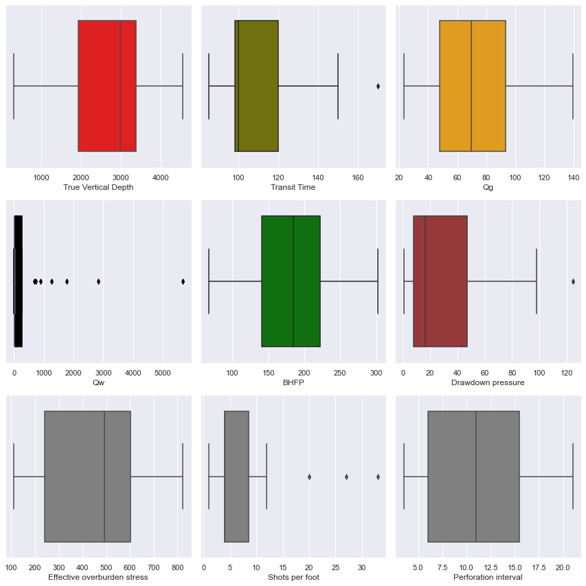

```python
f, axes =plt.subplots(3, 3, figsize=(12, 12))
sns.boxplot(df['True Vertical Depth'], color="red", ax=axes[0, 0]
)

sns.boxplot(df['Transit Time'], color="olive", ax=axes[0, 1]
)

sns.boxplot(df['Cohesive strength of formation'],color="blue",ax=axes[1,0])

#sns.boxplot(df['Rate Of Penetration'], color="blue", ax=axes
#[1, 0],0'Rate of Penetration (ft/hr)')

sns.boxplot(df['Qg'], color="orange", ax=axes[0,2])

sns.boxplot(df['Qw'], color="black",
ax=axes[1, 0])

sns.boxplot(df['BHFP'], color="green",
ax=axes[1, 1])

sns.boxplot(df['Drawdown pressure'], color="brown",
ax=axes[1, 2],)

sns.boxplot(df['Effective overburden stress'], color="gray", ax=axes[2, 0])


sns.boxplot(df['Shots per foot'], color="gray", ax=axes[2, 1])

sns.boxplot(df['Perforation interval'], color="gray", ax=axes[2, 2])


#sns.boxplot(df["Rate Of Penetration"],color="red",ax=axes[3,1],
#0"Rate of pentration")
plt.tight_layout()
plt.show()
```

```python
df
```

|  | True Vertical Depth | Transit Time | Cohesive strength of formation | Qg | Qw | BHFP | Drawdown pressure | Effective overburden stress | Shots per foot | Perforation interval | Sand Production Observed |
| --- | --- | --- | --- | --- | --- | --- | --- | --- | --- | --- | --- |
| 0 | 319 | 105 | 22.0 | 42.3 | 5672.000 | 133.2 | 27.8 | 651 | 4.0 | 14.0 | 1 |
| 1 | 3182 | 105 | 21.9 | 51.2 | 68.000 | 140.4 | 16.6 | 642 | 4.0 | 16.0 | 1 |
| 2 | 3366 | 100 | 24.7 | 66.9 | 157.000 | 156.2 | 18.9 | 601 | 4.0 | 6.0 | 1 |
| 3 | 3647 | 100 | 29.6 | 80.6 | 85.000 | 153.8 | 57.8 | 670 | 8.0 | 20.0 | 1 |
| 4 | 4548 | 85 | 53.2 | 48.0 | 886.000 | 209.1 | 58.9 | 823 | 4.0 | 18.0 | 1 |
| 5 | 4088 | 85 | 39.5 | 72.7 | 116.000 | 147.0 | 44.0 | 781 | 2.0 | 17.0 | 1 |
| 6 | 2100 | 115 | 10.8 | 28.5 | 724.000 | 160.1 | 8.9 | 300 | 4.0 | 15.5 | 1 |
| 7 | 1930 | 132 | 9.7 | 27.5 | 695.000 | 175.5 | 11.2 | 245 | 4.0 | 11.5 | 1 |
| 8 | 2139 | 112 | 11.1 | 36.8 | 280.000 | 185.5 | 6.1 | 283 | 4.0 | 10.5 | 1 |
| 9 | 2380 | 110 | 13.0 | 23.0 | 42.000 | 113.0 | 47.4 | 413 | 6.0 | 11.0 | 1 |
| 10 | 1122 | 150 | 5.7 | 108.0 | 0.000 | 107.0 | 8.0 | 115 | 12.0 | 10.5 | 1 |
| 11 | 1340 | 130 | 6.6 | 51.0 | 52.000 | 126.6 | 14.4 | 140 | 12.0 | 6.5 | 1 |
| 12 | 1070 | 170 | 5.5 | 82.0 | 70.000 | 103.8 | 0.7 | 111 | 4.0 | 9.0 | 1 |
| 13 | 1920 | 130 | 9.6 | 111.0 | 0.000 | 248.0 | 82.0 | 153 | 4.0 | 9.0 | 1 |
| 14 | 2530 | 100 | 14.3 | 58.0 | 68.000 | 302.2 | 97.8 | 242 | 4.0 | 4.5 | 1 |
| 15 | 1640 | 145 | 8.0 | 94.0 | 1260.000 | 189.0 | 46.8 | 150 | 12.0 | 10.0 | 1 |
| 16 | 2130 | 120 | 11.0 | 86.0 | 112.000 | 268.3 | 31.7 | 179 | 4.0 | 3.5 | 1 |
| 17 | 3655 | 100 | 19.8 | 69.8 | 1780.000 | 287.6 | 9.1 | 553 | 4.0 | 21.0 | 1 |
| 18 | 3668 | 100 | 30.0 | 75.8 | 150.000 | 272.3 | 9.2 | 571 | 4.0 | 21.0 | 1 |
| 19 | 1503 | 125 | 7.3 | 139.5 | 35.000 | 152.3 | 2.2 | 177 | 4.0 | 11.5 | 1 |
| 20 | 3170 | 100 | 21.7 | 48.0 | 2823.000 | 222.1 | 6.4 | 485 | 4.0 | 16.0 | 1 |
| 21 | 3197 | 95 | 22.1 | 73.0 | 273.000 | 184.6 | 48.6 | 535 | 2.0 | 12.0 | 0 |
| 22 | 3230 | 105 | 22.6 | 117.0 | 68.000 | 210.0 | 10.0 | 517 | 27.0 | 4.0 | 0 |
| 23 | 3684 | 95 | 30.3 | 108.7 | 36.000 | 266.6 | 59.7 | 581 | 1.0 | 12.0 | 0 |
| 24 | 3005 | 93 | 19.5 | 55.0 | 91.000 | 67.0 | 1.0 | 615 | 33.0 | 4.0 | 0 |
| 25 | 3790 | 85 | 32.5 | 93.4 | 77.000 | 217.2 | 124.4 | 654 | 8.5 | 12.0 | 0 |
| 26 | 2750 | 98 | 16.5 | 125.8 | 75.000 | 251.8 | 3.0 | 372 | 8.5 | 4.0 | 0 |
| 27 | 2983 | 98 | 19.2 | 48.0 | 28.000 | 102.0 | 6.1 | 581 | 12.0 | 4.0 | 0 |
| 28 | 3175 | 100 | 21.8 | 30.3 | 1.698 | 216.1 | 17.1 | 492 | 20.0 | 4.0 | 0 |

```python
df.columns
```

```
Index(['True Vertical Depth', 'Transit Time', 'Cohesive strength of formation',
       'Qg', 'Qw', 'BHFP', 'Drawdown pressure', 'Effective overburden stress',
       'Shots per foot', 'Perforation interval', 'Sand Production Observed'],
      dtype='object')
```

```python
df[["Cohesive strength of formation", 'Sand Production Observed']].groupby(['Sand Production Observed'], as_index=False).mean().sort_values(by='Sand Production Observed', ascending=False)

df[["Cohesive strength of formation", 'Sand Production Observed']].groupby(['Sand Production Observed'], as_index=False).mean().sort_values(by='Sand Production Observed', ascending=False)


#df[["Facies", 'Formation']].groupby(['Facies'], as_index=False).count().sort_values(by='Formation', ascending=False)
#df[["Facies", 'PE']].groupby(['Facies'], as_index=True).mean().sort_values(by='PE', ascending=False)
#df[["Facies", 'DeltaPHI']].groupby(['Facies'], as_index=True).mean().sort_values(by='DeltaPHI', ascending=False)
```

|  | Sand Production Observed | Cohesive strength of formation |
| --- | --- | --- |
| 1 | 1 | 17.857143 |
| 0 | 0 | 23.062500 |

```python
df[["Effective overburden stress", 'Sand Production Observed']].groupby(['Sand Production Observed'], as_index=False).mean().sort_values(by='Sand Production Observed', ascending=False)
```

|  | Sand Production Observed | Effective overburden stress |
| --- | --- | --- |
| 1 | 1 | 394.52381 |
| 0 | 0 | 543.37500 |

X is the dataframe that contains the features

```python
df
```

|  | True Vertical Depth | Transit Time | Cohesive strength of formation | Qg | Qw | BHFP | Drawdown pressure | Effective overburden stress | Shots per foot | Perforation interval | Sand Production Observed |
| --- | --- | --- | --- | --- | --- | --- | --- | --- | --- | --- | --- |
| 0 | 319 | 105 | 22.0 | 42.3 | 5672.000 | 133.2 | 27.8 | 651 | 4.0 | 14.0 | 1 |
| 1 | 3182 | 105 | 21.9 | 51.2 | 68.000 | 140.4 | 16.6 | 642 | 4.0 | 16.0 | 1 |
| 2 | 3366 | 100 | 24.7 | 66.9 | 157.000 | 156.2 | 18.9 | 601 | 4.0 | 6.0 | 1 |
| 3 | 3647 | 100 | 29.6 | 80.6 | 85.000 | 153.8 | 57.8 | 670 | 8.0 | 20.0 | 1 |
| 4 | 4548 | 85 | 53.2 | 48.0 | 886.000 | 209.1 | 58.9 | 823 | 4.0 | 18.0 | 1 |
| 5 | 4088 | 85 | 39.5 | 72.7 | 116.000 | 147.0 | 44.0 | 781 | 2.0 | 17.0 | 1 |
| 6 | 2100 | 115 | 10.8 | 28.5 | 724.000 | 160.1 | 8.9 | 300 | 4.0 | 15.5 | 1 |
| 7 | 1930 | 132 | 9.7 | 27.5 | 695.000 | 175.5 | 11.2 | 245 | 4.0 | 11.5 | 1 |
| 8 | 2139 | 112 | 11.1 | 36.8 | 280.000 | 185.5 | 6.1 | 283 | 4.0 | 10.5 | 1 |
| 9 | 2380 | 110 | 13.0 | 23.0 | 42.000 | 113.0 | 47.4 | 413 | 6.0 | 11.0 | 1 |
| 10 | 1122 | 150 | 5.7 | 108.0 | 0.000 | 107.0 | 8.0 | 115 | 12.0 | 10.5 | 1 |
| 11 | 1340 | 130 | 6.6 | 51.0 | 52.000 | 126.6 | 14.4 | 140 | 12.0 | 6.5 | 1 |
| 12 | 1070 | 170 | 5.5 | 82.0 | 70.000 | 103.8 | 0.7 | 111 | 4.0 | 9.0 | 1 |
| 13 | 1920 | 130 | 9.6 | 111.0 | 0.000 | 248.0 | 82.0 | 153 | 4.0 | 9.0 | 1 |
| 14 | 2530 | 100 | 14.3 | 58.0 | 68.000 | 302.2 | 97.8 | 242 | 4.0 | 4.5 | 1 |
| 15 | 1640 | 145 | 8.0 | 94.0 | 1260.000 | 189.0 | 46.8 | 150 | 12.0 | 10.0 | 1 |
| 16 | 2130 | 120 | 11.0 | 86.0 | 112.000 | 268.3 | 31.7 | 179 | 4.0 | 3.5 | 1 |
| 17 | 3655 | 100 | 19.8 | 69.8 | 1780.000 | 287.6 | 9.1 | 553 | 4.0 | 21.0 | 1 |
| 18 | 3668 | 100 | 30.0 | 75.8 | 150.000 | 272.3 | 9.2 | 571 | 4.0 | 21.0 | 1 |
| 19 | 1503 | 125 | 7.3 | 139.5 | 35.000 | 152.3 | 2.2 | 177 | 4.0 | 11.5 | 1 |
| 20 | 3170 | 100 | 21.7 | 48.0 | 2823.000 | 222.1 | 6.4 | 485 | 4.0 | 16.0 | 1 |
| 21 | 3197 | 95 | 22.1 | 73.0 | 273.000 | 184.6 | 48.6 | 535 | 2.0 | 12.0 | 0 |
| 22 | 3230 | 105 | 22.6 | 117.0 | 68.000 | 210.0 | 10.0 | 517 | 27.0 | 4.0 | 0 |
| 23 | 3684 | 95 | 30.3 | 108.7 | 36.000 | 266.6 | 59.7 | 581 | 1.0 | 12.0 | 0 |
| 24 | 3005 | 93 | 19.5 | 55.0 | 91.000 | 67.0 | 1.0 | 615 | 33.0 | 4.0 | 0 |
| 25 | 3790 | 85 | 32.5 | 93.4 | 77.000 | 217.2 | 124.4 | 654 | 8.5 | 12.0 | 0 |
| 26 | 2750 | 98 | 16.5 | 125.8 | 75.000 | 251.8 | 3.0 | 372 | 8.5 | 4.0 | 0 |
| 27 | 2983 | 98 | 19.2 | 48.0 | 28.000 | 102.0 | 6.1 | 581 | 12.0 | 4.0 | 0 |
| 28 | 3175 | 100 | 21.8 | 30.3 | 1.698 | 216.1 | 17.1 | 492 | 20.0 | 4.0 | 0 |

```python
X=df.iloc[:,:-1]
X
```

|  | True Vertical Depth | Transit Time | Cohesive strength of formation | Qg | Qw | BHFP | Drawdown pressure | Effective overburden stress | Shots per foot | Perforation interval |
| --- | --- | --- | --- | --- | --- | --- | --- | --- | --- | --- |
| 0 | 319 | 105 | 22.0 | 42.3 | 5672.000 | 133.2 | 27.8 | 651 | 4.0 | 14.0 |
| 1 | 3182 | 105 | 21.9 | 51.2 | 68.000 | 140.4 | 16.6 | 642 | 4.0 | 16.0 |
| 2 | 3366 | 100 | 24.7 | 66.9 | 157.000 | 156.2 | 18.9 | 601 | 4.0 | 6.0 |
| 3 | 3647 | 100 | 29.6 | 80.6 | 85.000 | 153.8 | 57.8 | 670 | 8.0 | 20.0 |
| 4 | 4548 | 85 | 53.2 | 48.0 | 886.000 | 209.1 | 58.9 | 823 | 4.0 | 18.0 |
| 5 | 4088 | 85 | 39.5 | 72.7 | 116.000 | 147.0 | 44.0 | 781 | 2.0 | 17.0 |
| 6 | 2100 | 115 | 10.8 | 28.5 | 724.000 | 160.1 | 8.9 | 300 | 4.0 | 15.5 |
| 7 | 1930 | 132 | 9.7 | 27.5 | 695.000 | 175.5 | 11.2 | 245 | 4.0 | 11.5 |
| 8 | 2139 | 112 | 11.1 | 36.8 | 280.000 | 185.5 | 6.1 | 283 | 4.0 | 10.5 |
| 9 | 2380 | 110 | 13.0 | 23.0 | 42.000 | 113.0 | 47.4 | 413 | 6.0 | 11.0 |
| 10 | 1122 | 150 | 5.7 | 108.0 | 0.000 | 107.0 | 8.0 | 115 | 12.0 | 10.5 |
| 11 | 1340 | 130 | 6.6 | 51.0 | 52.000 | 126.6 | 14.4 | 140 | 12.0 | 6.5 |
| 12 | 1070 | 170 | 5.5 | 82.0 | 70.000 | 103.8 | 0.7 | 111 | 4.0 | 9.0 |
| 13 | 1920 | 130 | 9.6 | 111.0 | 0.000 | 248.0 | 82.0 | 153 | 4.0 | 9.0 |
| 14 | 2530 | 100 | 14.3 | 58.0 | 68.000 | 302.2 | 97.8 | 242 | 4.0 | 4.5 |
| 15 | 1640 | 145 | 8.0 | 94.0 | 1260.000 | 189.0 | 46.8 | 150 | 12.0 | 10.0 |
| 16 | 2130 | 120 | 11.0 | 86.0 | 112.000 | 268.3 | 31.7 | 179 | 4.0 | 3.5 |
| 17 | 3655 | 100 | 19.8 | 69.8 | 1780.000 | 287.6 | 9.1 | 553 | 4.0 | 21.0 |
| 18 | 3668 | 100 | 30.0 | 75.8 | 150.000 | 272.3 | 9.2 | 571 | 4.0 | 21.0 |
| 19 | 1503 | 125 | 7.3 | 139.5 | 35.000 | 152.3 | 2.2 | 177 | 4.0 | 11.5 |
| 20 | 3170 | 100 | 21.7 | 48.0 | 2823.000 | 222.1 | 6.4 | 485 | 4.0 | 16.0 |
| 21 | 3197 | 95 | 22.1 | 73.0 | 273.000 | 184.6 | 48.6 | 535 | 2.0 | 12.0 |
| 22 | 3230 | 105 | 22.6 | 117.0 | 68.000 | 210.0 | 10.0 | 517 | 27.0 | 4.0 |
| 23 | 3684 | 95 | 30.3 | 108.7 | 36.000 | 266.6 | 59.7 | 581 | 1.0 | 12.0 |
| 24 | 3005 | 93 | 19.5 | 55.0 | 91.000 | 67.0 | 1.0 | 615 | 33.0 | 4.0 |
| 25 | 3790 | 85 | 32.5 | 93.4 | 77.000 | 217.2 | 124.4 | 654 | 8.5 | 12.0 |
| 26 | 2750 | 98 | 16.5 | 125.8 | 75.000 | 251.8 | 3.0 | 372 | 8.5 | 4.0 |
| 27 | 2983 | 98 | 19.2 | 48.0 | 28.000 | 102.0 | 6.1 | 581 | 12.0 | 4.0 |
| 28 | 3175 | 100 | 21.8 | 30.3 | 1.698 | 216.1 | 17.1 | 492 | 20.0 | 4.0 |

```python
y=df.iloc[:,-1].values
y=y.reshape(-1,1)
y
```

```
array([[1],
       [1],
       [1],
       [1],
       [1],
       [1],
       [1],
       [1],
       [1],
       [1],
       [1],
       [1],
       [1],
       [1],
       [1],
       [1],
       [1],
       [1],
       [1],
       [1],
       [1],
       [0],
       [0],
       [0],
       [0],
       [0],
       [0],
       [0],
       [0]], dtype=int64)
```

```python
#Standard Scaler for Data

scaler = StandardScaler(copy=True, with_mean=True, with_std=True)
X = scaler.fit_transform(X)

#showing data
#print('X \n' , X[:10])
#print('y \n' , y[:10])
```

```python
#Splitting data

X_train, X_test, y_train, y_test = train_test_split(X, y, test_size=0.33, random_state=44, shuffle =True)

#Splitted Data
#print('X_train shape is ' , X_train.shape)
#print('X_test shape is ' , X_test.shape)
#print('y_train shape is ' , y_train.shape)
#print('y_test shape is ' , y_test.shape)
```

```python
#Applying RandomForestClassifier Model
```

```python
RandomForestClassifierModel = RandomForestClassifier(criterion = 'gini',n_estimators=1000,max_depth=50,random_state=33) #criterion can be also : entropy
RandomForestClassifierModel.fit(X_train, y_train)

#Calculating Details
print('RandomForestClassifierModel Train Score is : ' , RandomForestClassifierModel.score(X_train, y_train))
print('RandomForestClassifierModel Test Score is : ' , RandomForestClassifierModel.score(X_test, y_test))
#print('RandomForestClassifierModel features importances are : ' , RandomForestClassifierModel.feature_importances_)
#print('----------------------------------------------------')
fi_RFC= RandomForestClassifierModel.feature_importances_
#Calculating Prediction
y_pred = RandomForestClassifierModel.predict(X_test)
y_pred_prob = RandomForestClassifierModel.predict_proba(X_test)
#print('Predicted Value for RandomForestClassifierModel is : ' , y_pred[:10])
#print('Prediction Probabilities Value for RandomForestClassifierModel is : ' , y_pred_prob[:10])
```

```
RandomForestClassifierModel Train Score is :  1.0
RandomForestClassifierModel Test Score is :  1.0
```

```
Confusion Matrix is :
 [[3 0]
 [0 7]]
```

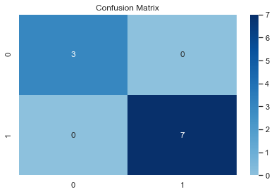

```python
#Calculating Confusion Matrix
CM = confusion_matrix(y_test, y_pred)
print('Confusion Matrix is : \n', CM)

# drawing confusion matrix
sns.heatmap(CM, center = True,annot=True,cmap="Blues")
plt.title("Confusion Matrix"), plt.tight_layout()
plt.show()
```

```python
#Calculating classification Report :
#classification_report(y_true, y_pred, labels=None, target_names=None,sample_weight=None, digits=2, output_dict=False)

ClassificationReport = classification_report(y_test,y_pred)
print('Classification Report is : ', ClassificationReport )
```

```
Classification Report is :                precision    recall  f1-score   support

           0       1.00      1.00      1.00         3
           1       1.00      1.00      1.00         7

    accuracy                           1.00        10
   macro avg       1.00      1.00      1.00        10
weighted avg       1.00      1.00      1.00        10
```

for knowing the most important features that affects the classifiction process

|  | 0 |
| --- | --- |
| Shots per foot | 0.180262 |
| Perforation interval | 0.157328 |
| Transit Time | 0.141700 |
| BHFP | 0.084436 |
| Drawdown pressure | 0.083621 |
| True Vertical Depth | 0.082803 |
| Qw | 0.080050 |
| Effective overburden stress | 0.079098 |
| Cohesive strength of formation | 0.067846 |
| Qg | 0.042858 |

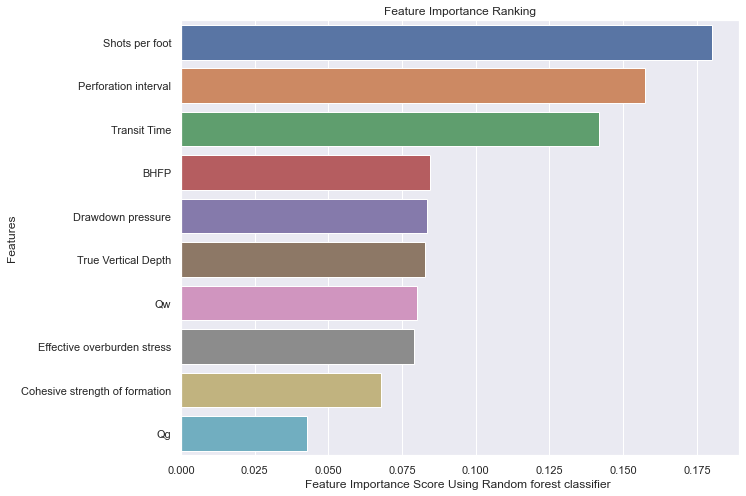

```python
features_names=df.columns[:-1]
features_names

plt.figure(figsize=(10,8))
feature_imp =pd.Series(fi_RFC,index=features_names).sort_values(ascending=False)
feature_imp


sns.barplot(x=feature_imp, y=feature_imp.index)
plt.xlabel('Feature Importance Score Using Random forest classifier ')
plt.ylabel('Features')
plt.title("Feature Importance Ranking")

feature_imp=pd.DataFrame(feature_imp)
feature_imp
```

from the above plot shots per foot ,Perforation interval ,transit time are the most important we can also visualize it by pair plot or Correlation matrix

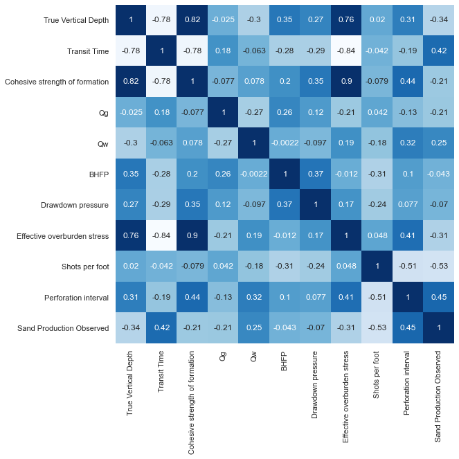

```python
#correlation matrix

corrmat = df.corr()
f, ax = plt.subplots(figsize=(12, 9))
sns.heatmap(corrmat, vmax=.8, square=True,annot=True, cmap="Blues",cbar=False)
plt.show()
```